# SQL Sales Analysis Using Relational Database JOINs

```python
import kagglehub

# Download latest version
path = kagglehub.dataset_download("moumitanandiroy/sql-data-set")

print("Path to dataset files:", path)
```

```
Path to dataset files: C:\Users\USER\.cache\kagglehub\datasets\moumitanandiroy\sql-data-set\versions\1
```

```python
import pandas as pd
import pyodbc
import os
import seaborn as sns
import matplotlib.pyplot as plt
import plotly.express as px
```

```python
print(os.listdir(path))
```

```
['Customers3.csv', 'OrderDetails3.csv', 'Orders3.csv', 'Products3.csv', 'Regions3.csv']
```

```python
A = pd.read_csv(os.path.join(path, "Customers3.csv"))
B = pd.read_csv(os.path.join(path, "OrderDetails3.csv"))
C = pd.read_csv(os.path.join(path, "Orders3.csv"))
D = pd.read_csv(os.path.join(path, "Products3.csv"))
E = pd.read_csv(os.path.join(path, "Regions3.csv"))
```

```python
A.head(3)
```

|  | CustomerID | CustomerName | Gender | City | State | Email | Phone |
| --- | --- | --- | --- | --- | --- | --- | --- |
| 0 | 101 | Customer 101 | Male | Delhi | Delhi | customer101@gmail.com | 9876540000 |
| 1 | 102 | Customer 102 | Female | Lucknow | Uttar Pradesh | customer102@gmail.com | 9876540001 |
| 2 | 103 | Customer 103 | Male | Mumbai | Maharashtra | customer103@gmail.com | 9876540002 |

```python
B.head(3)
```

|  | OrderDetailID | OrderID | ProductID | Quantity |
| --- | --- | --- | --- | --- |
| 0 | 401 | 301 | 201 | 1 |
| 1 | 402 | 302 | 202 | 2 |
| 2 | 403 | 303 | 203 | 3 |

```python
C.head(3)
```

|  | OrderID | CustomerID | OrderDate | PaymentMethod |
| --- | --- | --- | --- | --- |
| 0 | 301 | 101 | 2025-01-01 | UPI |
| 1 | 302 | 102 | 2025-01-02 | Cash |
| 2 | 303 | 103 | 2025-01-03 | Debit Card |

```python
D.head(3)
```

|  | ProductID | ProductName | Category | CostPrice | SellingPrice |
| --- | --- | --- | --- | --- | --- |
| 0 | 201 | Product 201 | Electronics | 500 | 650.0 |
| 1 | 202 | Product 202 | Furniture | 620 | 806.0 |
| 2 | 203 | Product 203 | Stationery | 740 | 962.0 |

```python
E.head(3)
```

|  | RegionID | State | Region |
| --- | --- | --- | --- |
| 0 | 1 | Delhi | North |
| 1 | 2 | Uttar Pradesh | North |
| 2 | 3 | Maharashtra | West |

# DATA CLEANING

**CHECKING NULLS**

```python
AA = A.isnull().sum()
BB = B.isnull().sum()
CC = C.isnull().sum()
DD = D.isnull().sum()
EE = E.isnull().sum()
print(AA,BB,CC,DD,EE)
```

```
CustomerID      0
CustomerName    0
Gender          0
City            0
State           0
Email           0
Phone           0
dtype: int64 OrderDetailID    0
OrderID          0
ProductID        0
Quantity         0
dtype: int64 OrderID          0
CustomerID       0
OrderDate        0
PaymentMethod    0
dtype: int64 ProductID       0
ProductName     0
Category        0
CostPrice       0
SellingPrice    0
dtype: int64 RegionID    0
State       0
Region      0
dtype: int64
```

**CHECKING DUPLICATES**

```python
AA = A.duplicated().sum()
BB = B.duplicated().sum()
CC = C.duplicated().sum()
DD = D.duplicated().sum()
EE = E.duplicated().sum()
print(AA,BB,CC,DD,EE)
```

```
0 0 0 0 0
```

**CHECKING ANY UNKNOWN**

```python
AA = A["City"].unique()
DD = D["Category"].unique()
EE = E["State"].unique()
print(AA,DD,EE)
```

```
['Delhi' 'Lucknow' 'Mumbai' 'Kolkata' 'Patna' 'Jaipur' 'Ahmedabad'
 'Chennai' 'Hyderabad' 'Bhubaneswar'] ['Electronics' 'Furniture' 'Stationery' 'Appliances' 'Accessories'] ['Delhi' 'Uttar Pradesh' 'Maharashtra' 'West Bengal' 'Bihar' 'Rajasthan'
 'Gujarat' 'Tamil Nadu' 'Telangana' 'Odisha']
```

**CHECKING FOR INCONSISTENCIES**

```python
AA = A.groupby("CustomerID")["CustomerName"].nunique().max()
BB = B.groupby("OrderID")["ProductID"].nunique().max()
CC = C.groupby("OrderID")["OrderDate"].nunique().max()
print(AA,BB,CC)
```

```
1 1 1
```

### DATA QUALITY CHECK

The dataset has been thoroughly checked for data quality:

1. **Missing Values (NULLs):** None found
2. **Duplicate Records:** None found
3. **Unknown/Unexpected Unique Values:** None found
4. **Data Inconsistencies:** None found

**Conclusion:** The data has been thoroughly validated and is ready to be imported into **SQL Server** for further analysis.

```python
conn = pyodbc.connect(
"DRIVER={ODBC Driver 17 for SQL Server};"
"SERVER=DESKTOP-KRJR07A\SQLEXPRESS;"
"DATABASE=STORE_DATA;"
"Trusted_connection=yes;"
)
print("CONNECT")
```

```
CONNECT
```

```python
from sqlalchemy import create_engine
import urllib

params = urllib.parse.quote_plus(
    "DRIVER={ODBC Driver 17 for SQL Server};"
    r"SERVER=DESKTOP-KRJR07A\SQLEXPRESS;"
    "DATABASE=STORE_DATA;"
    "Trusted_Connection=yes;"
)

engine = create_engine(
    "mssql+pyodbc:///?odbc_connect=" + params
)
```

```python
A.to_sql("Customers3", engine, if_exists="replace", index=False)

B.to_sql("OrderDetails3", engine, if_exists="replace", index=False)

C.to_sql("Orders3", engine, if_exists="replace", index=False)

D.to_sql("Products3", engine, if_exists="replace", index=False)

E.to_sql("Regions3", engine, if_exists="replace", index=False)
```

```
10
```

```python
pd.read_sql("""
SELECT TABLE_NAME
FROM INFORMATION_SCHEMA.TABLES
WHERE TABLE_TYPE = 'BASE TABLE'
""",engine)
```

|  | TABLE_NAME |
| --- | --- |
| 0 | Sample_Superstore |
| 1 | customers |
| 2 | deliveries |
| 3 | orders |
| 4 | restaurants |
| 5 | riders. |
| 6 | kiez_prices_monthly |
| 7 | new_construction |
| 8 | rentals |
| 9 | secondary_sales |
| 10 | transit_stations.csv |
| 11 | marketing_sales_dataset |
| 12 | mango_sales_100000 |
| 13 | Different_stores_dataset |
| 14 | amazon_sales_data |
| 15 | Customers3 |
| 16 | OrderDetails3 |
| 17 | Orders3 |
| 18 | Products3 |
| 19 | Regions3 |

```python
# A
pd.read_sql("""
SELECT TOP 3*
FROM Customers3

""",engine)
```

|  | CustomerID | CustomerName | Gender | City | State | Email | Phone |
| --- | --- | --- | --- | --- | --- | --- | --- |
| 0 | 101 | Customer 101 | Male | Delhi | Delhi | customer101@gmail.com | 9876540000 |
| 1 | 102 | Customer 102 | Female | Lucknow | Uttar Pradesh | customer102@gmail.com | 9876540001 |
| 2 | 103 | Customer 103 | Male | Mumbai | Maharashtra | customer103@gmail.com | 9876540002 |

```python
# B
pd.read_sql("""
SELECT TOP 3*
FROM OrderDetails3

""",engine)
```

|  | OrderDetailID | OrderID | ProductID | Quantity |
| --- | --- | --- | --- | --- |
| 0 | 401 | 301 | 201 | 1 |
| 1 | 402 | 302 | 202 | 2 |
| 2 | 403 | 303 | 203 | 3 |

```python
# C
pd.read_sql("""
SELECT TOP 3*
FROM Orders3

""",engine)
```

|  | OrderID | CustomerID | OrderDate | PaymentMethod |
| --- | --- | --- | --- | --- |
| 0 | 301 | 101 | 2025-01-01 | UPI |
| 1 | 302 | 102 | 2025-01-02 | Cash |
| 2 | 303 | 103 | 2025-01-03 | Debit Card |

```python
# D
pd.read_sql("""
SELECT TOP 3*
FROM Products3

""",engine)
```

|  | ProductID | ProductName | Category | CostPrice | SellingPrice |
| --- | --- | --- | --- | --- | --- |
| 0 | 201 | Product 201 | Electronics | 500 | 650.0 |
| 1 | 202 | Product 202 | Furniture | 620 | 806.0 |
| 2 | 203 | Product 203 | Stationery | 740 | 962.0 |

```python
# E
pd.read_sql("""
SELECT TOP 3*
FROM Regions3

""",engine)
```

|  | RegionID | State | Region |
| --- | --- | --- | --- |
| 0 | 1 | Delhi | North |
| 1 | 2 | Uttar Pradesh | North |
| 2 | 3 | Maharashtra | West |

## LEFT JOIN

```python
pd.read_sql("""
SELECT TOP 3*
FROM Customers3 AS C
LEFT JOIN Orders3 AS O
ON C.CustomerID = O.CustomerID
LEFT JOIN OrderDetails3 AS OD
ON OD.OrderId = O.OrderID
LEFT JOIN Regions3 AS R
ON R.State = C.State
LEFT JOIN Products3 AS P
ON P.ProductId = OD.ProductID

""",engine)
```

|  | CustomerID | CustomerName | Gender | City | State | Email | Phone | OrderID | CustomerID | OrderDate | ... | ProductID | Quantity | RegionID | State | Region | ProductID | ProductName | Category | CostPrice | SellingPrice |
| --- | --- | --- | --- | --- | --- | --- | --- | --- | --- | --- | --- | --- | --- | --- | --- | --- | --- | --- | --- | --- | --- |
| 0 | 101 | Customer 101 | Male | Delhi | Delhi | customer101@gmail.com | 9876540000 | 301 | 101 | 2025-01-01 | ... | 201 | 1 | 1 | Delhi | North | 201 | Product 201 | Electronics | 500 | 650.0 |
| 1 | 101 | Customer 101 | Male | Delhi | Delhi | customer101@gmail.com | 9876540000 | 301 | 101 | 2025-01-01 | ... | 201 | 1 | 1 | Delhi | North | 201 | Product 201 | Electronics | 500 | 650.0 |
| 2 | 101 | Customer 101 | Male | Delhi | Delhi | customer101@gmail.com | 9876540000 | 401 | 101 | 2025-04-11 | ... | 201 | 1 | 1 | Delhi | North | 201 | Product 201 | Electronics | 500 | 650.0 |

3 rows × 23 columns

**RIGHT JOIN**

```python
pd.read_sql("""
SELECT TOP 3*
FROM Customers3 AS C
RIGHT JOIN Orders3 AS O
ON C.CustomerID = O.CustomerID
RIGHT JOIN OrderDetails3 AS OD
ON OD.OrderId = O.OrderID
RIGHT JOIN Regions3 AS R
ON R.State = C.State
RIGHT JOIN Products3 AS P
ON P.ProductId = OD.ProductID

""",engine)
```

|  | CustomerID | CustomerName | Gender | City | State | Email | Phone | OrderID | CustomerID | OrderDate | ... | ProductID | Quantity | RegionID | State | Region | ProductID | ProductName | Category | CostPrice | SellingPrice |
| --- | --- | --- | --- | --- | --- | --- | --- | --- | --- | --- | --- | --- | --- | --- | --- | --- | --- | --- | --- | --- | --- |
| 0 | 101 | Customer 101 | Male | Delhi | Delhi | customer101@gmail.com | 9876540000 | 301 | 101 | 2025-01-01 | ... | 201 | 1 | 1 | Delhi | North | 201 | Product 201 | Electronics | 500 | 650.0 |
| 1 | 151 | Customer 151 | Male | Delhi | Delhi | customer151@gmail.com | 9876540050 | 351 | 151 | 2025-02-20 | ... | 201 | 1 | 1 | Delhi | North | 201 | Product 201 | Electronics | 500 | 650.0 |
| 2 | 101 | Customer 101 | Male | Delhi | Delhi | customer101@gmail.com | 9876540000 | 401 | 101 | 2025-04-11 | ... | 201 | 1 | 1 | Delhi | North | 201 | Product 201 | Electronics | 500 | 650.0 |

3 rows × 23 columns

**INNER JOIN**

```python
pd.read_sql("""
SELECT TOP 3*
FROM Customers3 AS C
INNER JOIN Orders3 AS O
ON C.CustomerID = O.CustomerID
INNER JOIN OrderDetails3 AS OD
ON OD.OrderId = O.OrderID
INNER JOIN Regions3 AS R
ON R.State = C.State
INNER JOIN Products3 AS P
ON P.ProductId = OD.ProductID

""",engine)
```

|  | CustomerID | CustomerName | Gender | City | State | Email | Phone | OrderID | CustomerID | OrderDate | ... | ProductID | Quantity | RegionID | State | Region | ProductID | ProductName | Category | CostPrice | SellingPrice |
| --- | --- | --- | --- | --- | --- | --- | --- | --- | --- | --- | --- | --- | --- | --- | --- | --- | --- | --- | --- | --- | --- |
| 0 | 101 | Customer 101 | Male | Delhi | Delhi | customer101@gmail.com | 9876540000 | 301 | 101 | 2025-01-01 | ... | 201 | 1 | 1 | Delhi | North | 201 | Product 201 | Electronics | 500 | 650.0 |
| 1 | 101 | Customer 101 | Male | Delhi | Delhi | customer101@gmail.com | 9876540000 | 301 | 101 | 2025-01-01 | ... | 201 | 1 | 1 | Delhi | North | 201 | Product 201 | Electronics | 500 | 650.0 |
| 2 | 101 | Customer 101 | Male | Delhi | Delhi | customer101@gmail.com | 9876540000 | 401 | 101 | 2025-04-11 | ... | 201 | 1 | 1 | Delhi | North | 201 | Product 201 | Electronics | 500 | 650.0 |

3 rows × 23 columns

**TOTAL SALES BY CITY & STATE**

```python
pd.read_sql("""
SELECT C.City, R.State,
SUM(P.SellingPrice*OD.Quantity) AS TOTAL_SALES
FROM Customers3 AS C
INNER JOIN Orders3 AS O
ON C.CustomerID = O.CustomerID
INNER JOIN OrderDetails3 AS OD
ON OD.OrderId = O.OrderID
INNER JOIN Regions3 AS R
ON R.State = C.State
INNER JOIN Products3 AS P
ON P.ProductId = OD.ProductID
GROUP BY C.City, R.State
ORDER BY TOTAL_SALES DESC;
""",engine)
```

|  | City | State | TOTAL_SALES |
| --- | --- | --- | --- |
| 0 | Bhubaneswar | Odisha | 1552200.0 |
| 1 | Patna | Bihar | 1318200.0 |
| 2 | Hyderabad | Telangana | 1204320.0 |
| 3 | Kolkata | West Bengal | 1017120.0 |
| 4 | Chennai | Tamil Nadu | 875160.0 |
| 5 | Mumbai | Maharashtra | 734760.0 |
| 6 | Ahmedabad | Gujarat | 564720.0 |
| 7 | Lucknow | Uttar Pradesh | 471120.0 |
| 8 | Jaipur | Rajasthan | 273000.0 |
| 9 | Delhi | Delhi | 226200.0 |

**TOTAL SALES BY GENDER**

```python
pd.read_sql("""
SELECT C.Gender,
SUM(P.SellingPrice*OD.Quantity) AS TOTAL_SALES
FROM Customers3 AS C
INNER JOIN Orders3 AS O
ON C.CustomerID = O.CustomerID
INNER JOIN OrderDetails3 AS OD
ON OD.OrderId = O.OrderID
INNER JOIN Regions3 AS R
ON R.State = C.State
INNER JOIN Products3 AS P
ON P.ProductId = OD.ProductID
GROUP BY C.Gender
ORDER BY TOTAL_SALES DESC;
""",engine)
```

|  | Gender | TOTAL_SALES |
| --- | --- | --- |
| 0 | Female | 4188600.0 |
| 1 | Male | 4048200.0 |

**TOTAL SALES BY CATEGORY**

```python
pd.read_sql("""
SELECT P.Category,
SUM(P.SellingPrice*OD.Quantity) AS TOTAL_SALES
FROM Customers3 AS C
INNER JOIN Orders3 AS O
ON C.CustomerID = O.CustomerID
INNER JOIN OrderDetails3 AS OD
ON OD.OrderId = O.OrderID
INNER JOIN Regions3 AS R
ON R.State = C.State
INNER JOIN Products3 AS P
ON P.ProductId = OD.ProductID
GROUP BY P.Category
ORDER BY TOTAL_SALES DESC;
""",engine)
```

|  | Category | TOTAL_SALES |
| --- | --- | --- |
| 0 | Accessories | 2870400.0 |
| 1 | Appliances | 2221440.0 |
| 2 | Stationery | 1609920.0 |
| 3 | Furniture | 1035840.0 |
| 4 | Electronics | 499200.0 |

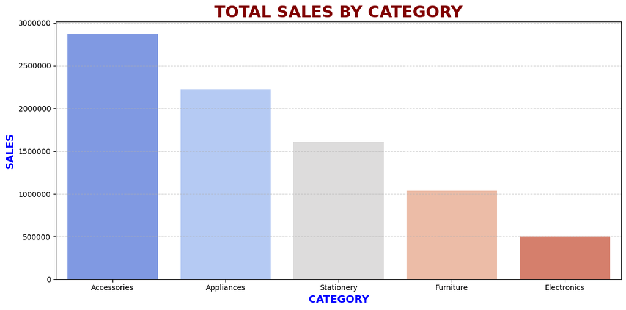

```python
sales_cat = pd.read_sql("""
SELECT P.Category AS CATEGORY,
SUM(P.SellingPrice*OD.Quantity) AS TOTAL_SALES
FROM Customers3 AS C
INNER JOIN Orders3 AS O
ON C.CustomerID = O.CustomerID
INNER JOIN OrderDetails3 AS OD
ON OD.OrderId = O.OrderID
INNER JOIN Regions3 AS R
ON R.State = C.State
INNER JOIN Products3 AS P
ON P.ProductId = OD.ProductID
GROUP BY P.Category
ORDER BY TOTAL_SALES DESC;
""",engine)
plt.figure(figsize=(12,6))
sns.barplot(data= sales_cat, x= "CATEGORY", y= "TOTAL_SALES", palette="coolwarm", legend=False, hue="CATEGORY")
plt.title("TOTAL SALES BY CATEGORY", color="maroon", fontsize=22, fontweight="bold")
plt.xlabel("CATEGORY", fontsize=14, fontweight="bold", color="blue")
plt.ylabel("SALES", fontsize=14, fontweight="bold", color="blue")
plt.grid(axis="y", linestyle="--", alpha=0.5)
plt.ticklabel_format(style="plain", axis="y")
plt.tight_layout()
plt.show()
```

**MONTHLY SALES**

```python
pd.read_sql("""
SELECT DATENAME(MONTH, O.OrderDate) AS MONTH_NAME,
MONTH(O.OrderDate) AS MONTH,YEAR(O.OrderDate) AS YEAR,
SUM(P.SellingPrice*OD.Quantity) AS TOTAL_SALES
FROM Customers3 AS C
INNER JOIN Orders3 AS O
ON C.CustomerID = O.CustomerID
INNER JOIN OrderDetails3 AS OD
ON OD.OrderId = O.OrderID
INNER JOIN Regions3 AS R
ON R.State = C.State
INNER JOIN Products3 AS P
ON P.ProductId = OD.ProductID
GROUP BY
DATENAME(MONTH, O.OrderDate),
MONTH(O.OrderDate),YEAR(O.OrderDate)
ORDER BY MONTH;
""", engine)
```

|  | MONTH_NAME | MONTH | YEAR | TOTAL_SALES |
| --- | --- | --- | --- | --- |
| 0 | January | 1 | 2025 | 1475240.0 |
| 1 | February | 2 | 2025 | 1638000.0 |
| 2 | March | 3 | 2025 | 1641640.0 |
| 3 | April | 4 | 2025 | 1834560.0 |
| 4 | May | 5 | 2025 | 1105780.0 |
| 5 | June | 6 | 2025 | 541580.0 |

**DAILY SALES**

```python
pd.read_sql("""
SELECT DATENAME(WEEKDAY, O.OrderDate) AS DAY_NAME,
SUM(P.SellingPrice*OD.Quantity) AS TOTAL_SALES
FROM Customers3 AS C
INNER JOIN Orders3 AS O
ON C.CustomerID = O.CustomerID
INNER JOIN OrderDetails3 AS OD
ON OD.OrderId = O.OrderID
INNER JOIN Regions3 AS R
ON R.State = C.State
INNER JOIN Products3 AS P
ON P.ProductId = OD.ProductID
GROUP BY DATENAME(WEEKDAY, O.OrderDate)
ORDER BY CASE DATENAME(WEEKDAY, O.OrderDate)
WHEN 'Monday' THEN 1
WHEN 'Tuesday' THEN 2
WHEN 'Wednesday' THEN 3
WHEN 'Thursday' THEN 4
WHEN 'Friday' THEN 5
WHEN 'Saturday' THEN 6
WHEN 'Sunday' THEN 7
END;
""", engine)
```

|  | DAY_NAME | TOTAL_SALES |
| --- | --- | --- |
| 0 | Monday | 1148992.0 |
| 1 | Tuesday | 1202448.0 |
| 2 | Wednesday | 1234792.0 |
| 3 | Thursday | 1180712.0 |
| 4 | Friday | 1177124.0 |
| 5 | Saturday | 1111188.0 |
| 6 | Sunday | 1181544.0 |

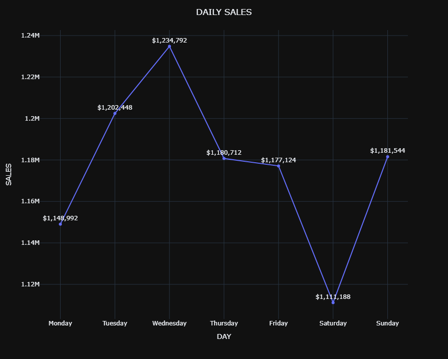

```python
DAILY_SALES = pd.read_sql("""
SELECT DATENAME(WEEKDAY, O.OrderDate) AS DAY_NAME,
SUM(P.SellingPrice*OD.Quantity) AS TOTAL_SALES
FROM Customers3 AS C
INNER JOIN Orders3 AS O
ON C.CustomerID = O.CustomerID
INNER JOIN OrderDetails3 AS OD
ON OD.OrderId = O.OrderID
INNER JOIN Regions3 AS R
ON R.State = C.State
INNER JOIN Products3 AS P
ON P.ProductId = OD.ProductID
GROUP BY DATENAME(WEEKDAY, O.OrderDate)
ORDER BY CASE DATENAME(WEEKDAY, O.OrderDate)
WHEN 'Monday' THEN 1
WHEN 'Tuesday' THEN 2
WHEN 'Wednesday' THEN 3
WHEN 'Thursday' THEN 4
WHEN 'Friday' THEN 5
WHEN 'Saturday' THEN 6
WHEN 'Sunday' THEN 7
END;
""", engine)
fig = px.line(DAILY_SALES, x= "DAY_NAME", y= "TOTAL_SALES", markers=True, text= "TOTAL_SALES")
fig.update_traces(texttemplate="$%{text:,.0f}", textposition="top center")
fig.update_layout(title= "DAILY SALES", template= "plotly_dark", title_x= 0.5, xaxis_title= "DAY", yaxis_title= "SALES", height=700, width= 1000)
```

## CONCLUSION

This project demonstrates how SQL JOINs can be used to combine data from multiple related tables and transform it into meaningful business analysis. The dataset was checked for missing values, duplicates, unexpected values, and data inconsistencies before being imported into SQL Server. The validation checks showed no NULL values, duplicates, or identified inconsistencies, making the data suitable for analysis.

Using `INNER JOIN`, `LEFT JOIN`, and `RIGHT JOIN`, customer, order, order-detail, product, and regional information was connected to create a complete view of sales transactions.

Overall, the project demonstrates the practical use of SQL JOINs, aggregation, `GROUP BY`, date functions, conditional sorting, and data visualization to analyze sales performance from relational datasets. It shows how multiple normalized tables can be connected and analyzed to identify sales patterns across **locations, customer segments, product categories, months, and weekdays**.

## RECOMMENDATIONS

Based on the sales analysis, the following recommendations can help improve business performance:

1. **Focus on High-Performing Cities and States**
   - Increase marketing efforts and inventory levels in top-performing cities and states to maximize revenue.
   - Study the characteristics of these locations to replicate their success in lower-performing areas.
2. **Promote High-Selling Product Categories**
   - Allocate more stock and promotional campaigns to categories generating the highest sales.
   - Introduce bundle offers and discounts for popular products.
3. **Improve Low-Performing Categories**
   - Analyze customer preferences, pricing, and competition for categories with lower sales.
   - Consider targeted promotions to increase demand.
4. **Optimize Monthly Sales Performance**
   - Since sales vary by month, create seasonal marketing strategies and inventory planning.
   - Increase promotional activities before high-sales periods.
5. **Utilize Day-Wise Sales Trends**
   - Allocate staff, inventory, and marketing budgets according to high-performing weekdays.
   - Launch special offers on low-performing days to improve sales.
6. **Strengthen Customer Relationship Management**
   - Identify top customers and implement loyalty programs to increase repeat purchases.
   - Analyze customer purchasing behavior for personalized marketing campaigns.
7. **Regional Business Expansion**
   - Invest more resources in high-performing regions while investigating the reasons for lower sales in other areas.
8. **Future Analysis**
   - Extend the project by adding profit analysis, customer segmentation, and top products by region using advanced SQL functions such as `RANK()` and `PARTITION BY`.